# Task10

Tomas Kozlovskis

2016 m balandis 18 d

## TASK 10.1

For this exercise, use the price of a dozen eggs in the United States from 1900–1993 (data set eggs). Experiment with the various options in the holt() function to see how much the forecasts change with damped or exponential trend. Also try changing the parameter values for alfa and beta to see how they affect the forecasts. Try to develop an intuition of what each parameter and argument is doing to the forecasts. Which model gives the best RMSE? Do the residuals from the best model look like white noise?

Firstly, let’s take a look at our original data, which contains observations of prices of dozen of eggs in USA from 1900 until 1993.

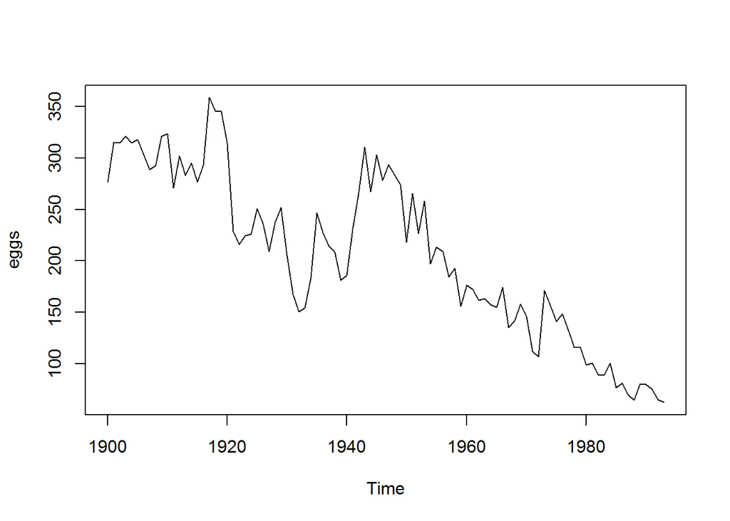

```r
fit2 <- holt(eggs, h=100)
```

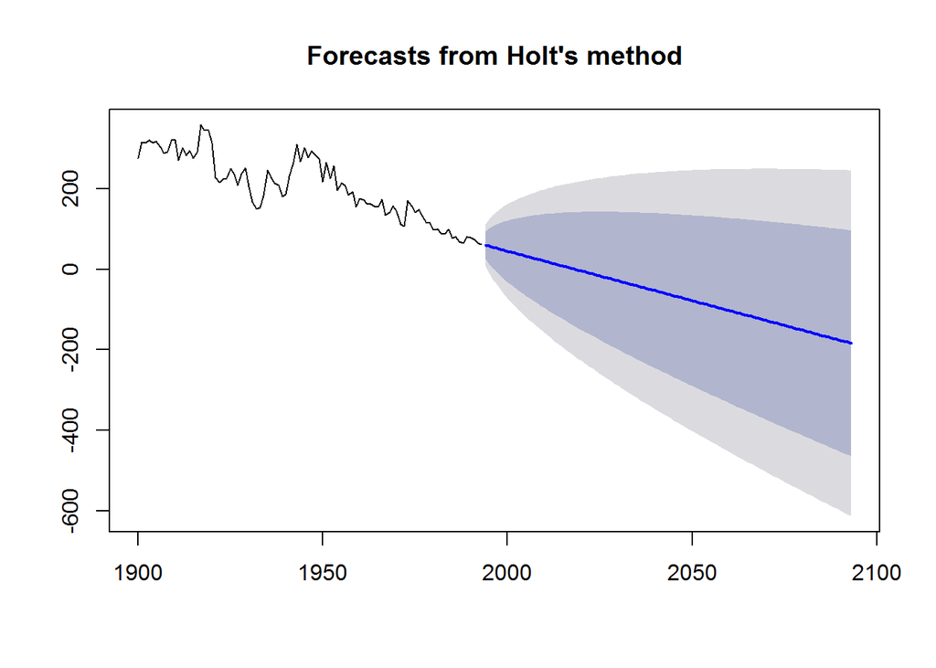

```
##                      ME     RMSE      MAE       MPE     MAPE      MASE
## Training set -0.2037058 26.52594 19.17071 -1.301754 9.676181 0.9456624
##                     ACF1
## Training set 0.009698614
```

```r
fit4 <- holt(eggs, h=100, damped=F, exponential = T)
```

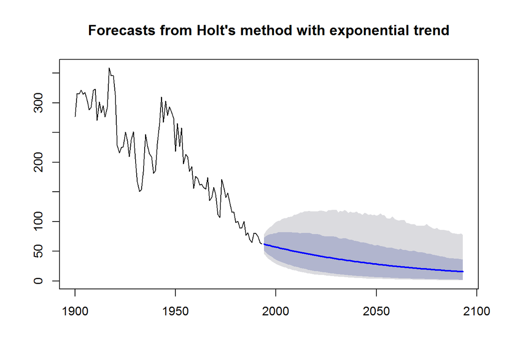

```
##                     ME     RMSE      MAE       MPE     MAPE      MASE
## Training set 0.4089821 26.39044 19.21208 -1.317409 9.752296 0.9477032
##                    ACF1
## Training set 0.01075801
```

```r
fit5.1<-holt(eggs, h=100, damped = TRUE)
```

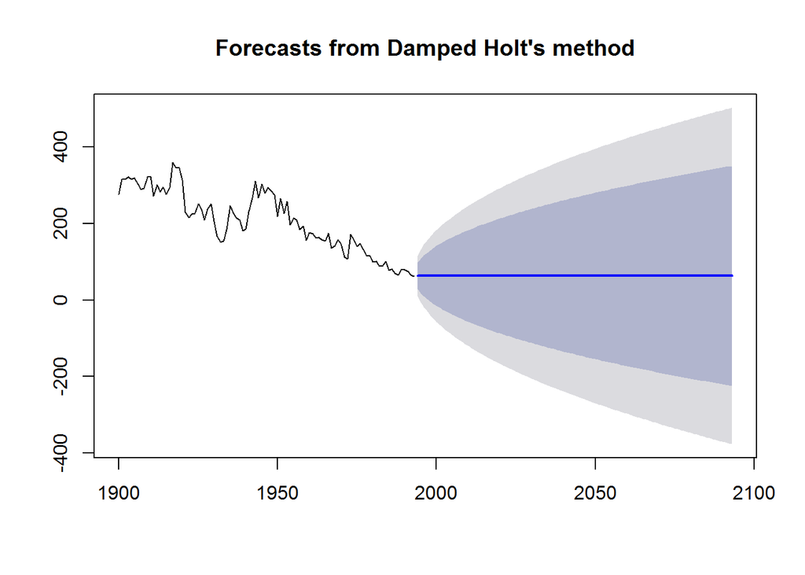

```
##                     ME     RMSE      MAE       MPE     MAPE      MASE
## Training set -3.184169 26.66343 19.49651 -3.053133 10.10672 0.9617335
##                      ACF1
## Training set -0.007413481
```

Because of the fact, that our data has a trend, this forecast is a constant.

```r
fit6 <- holt(eggs, h=100, damped=FALSE, beta=0.0009)
```

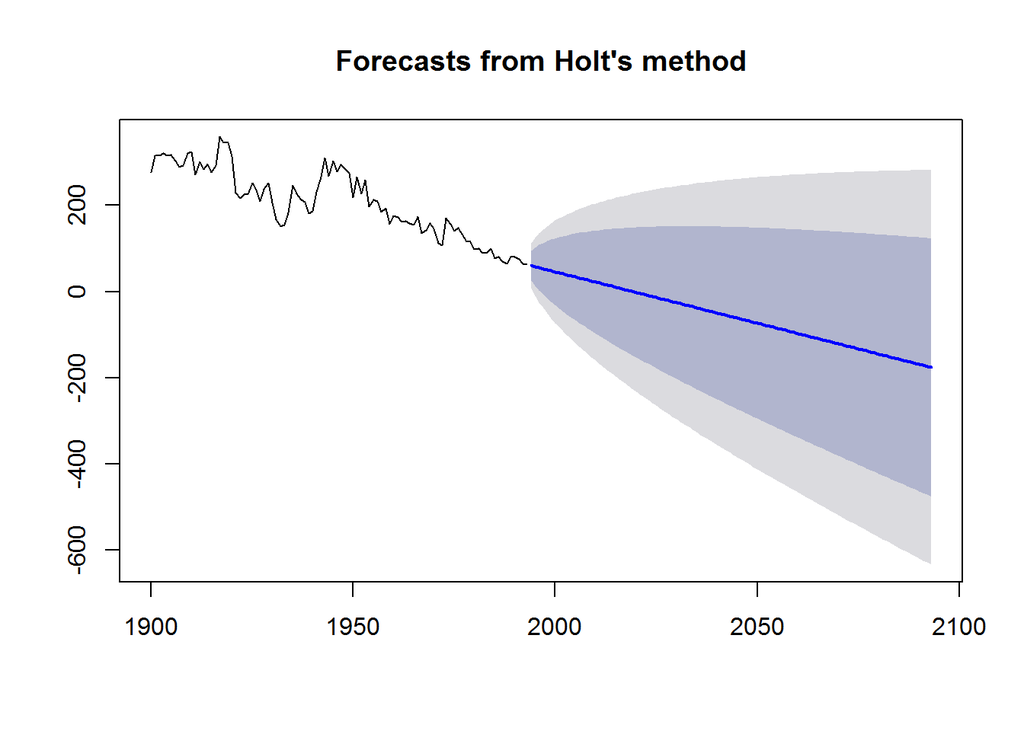

```
##                       ME     RMSE      MAE       MPE     MAPE      MASE
## Training set -0.03783803 26.43092 19.05538 -1.251858 9.654121 0.9399734
##                     ACF1
## Training set 0.007277623
```

```r
fit7 <- holt(eggs, h=100, damped =T, exponential = T, beta = 0.001)
```

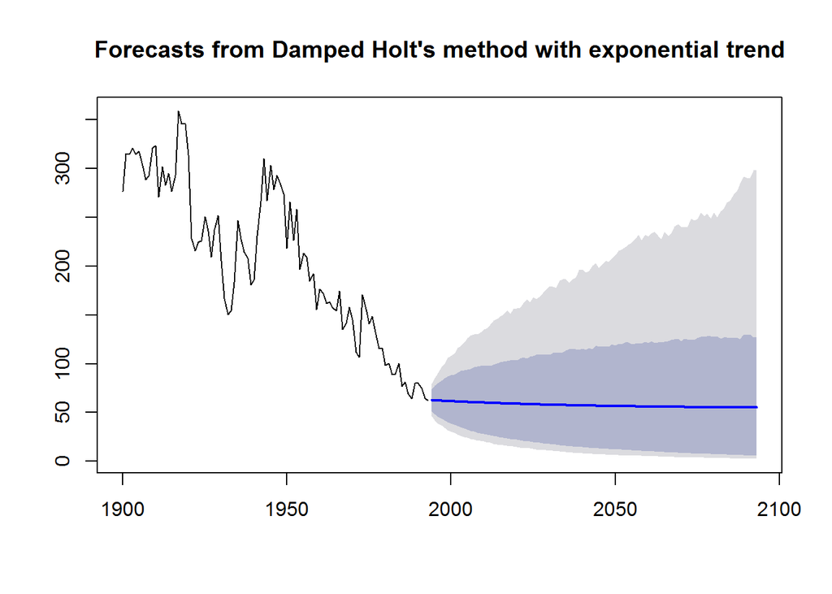

```
##                      ME     RMSE     MAE       MPE     MAPE      MASE
## Training set -0.9735585 26.53852 19.5145 -2.135303 10.01812 0.9626209
##                     ACF1
## Training set 0.005667489
```

```r
fit8 <- holt(eggs, h=100, damped = T, exponential = T, beta = 0.2)
```

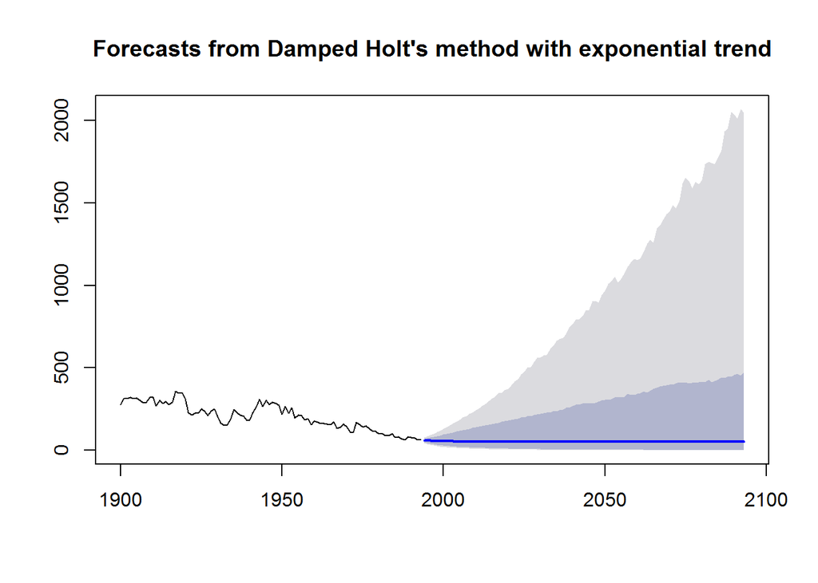

```
##                     ME     RMSE     MAE       MPE     MAPE     MASE
## Training set -2.849399 27.99889 21.2013 -2.533395 10.76992 1.045828
##                     ACF1
## Training set -0.04486834
```

```r
fit9 <- holt(eggs, h=100, damped =T, exponential = T, alpha = 0.05)
```

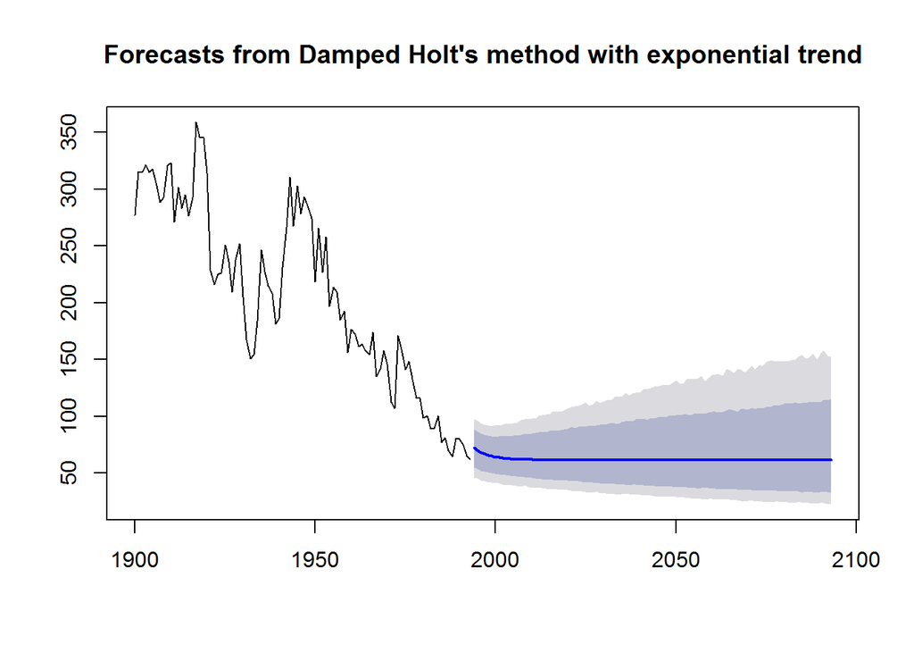

```
##                     ME     RMSE      MAE       MPE     MAPE     MASE
## Training set -13.18793 39.58573 31.62214 -10.66323 17.55554 1.559873
##                   ACF1
## Training set 0.7110442
```

Forecast is the best when model estimates alpha that fits data best

```r
fit10<-holt(eggs, h=100, damped = T, exponential = T)
```

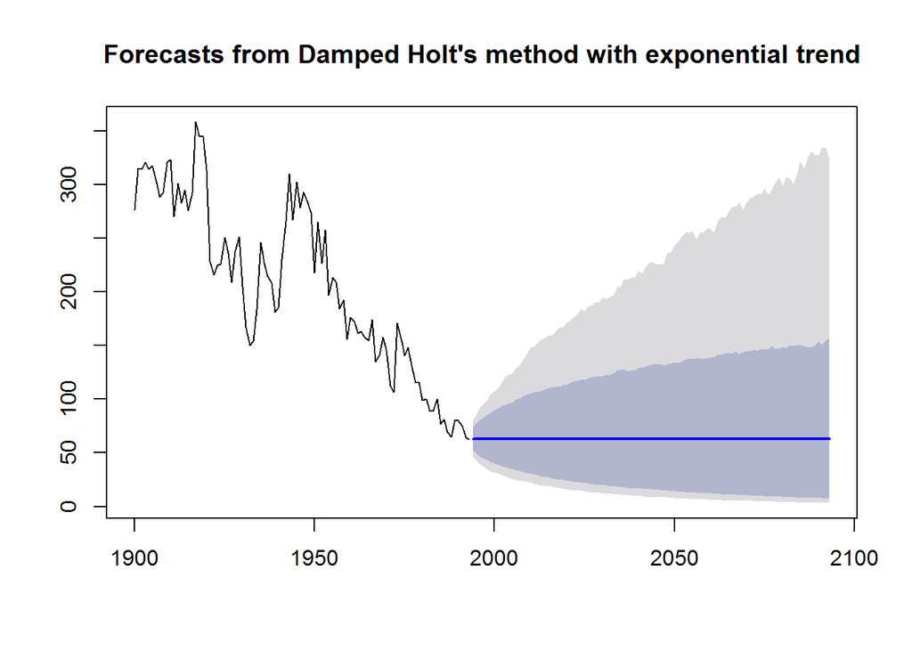

```
##                    ME     RMSE      MAE       MPE     MAPE      MASE
## Training set -2.83663 26.66184 19.53357 -2.945087 10.11569 0.9635619
##                      ACF1
## Training set 0.0009629126
```

```
## Damped Holt's method with exponential trend
##
## Call:
##  holt(x = eggs, h = 100, damped = T, exponential = T)
##
##   Smoothing parameters:
##     alpha = 0.8342
##     beta  = 1e-04
##     phi   = 0.8888
##
##   Initial states:
##     l = 304.8251
##     b = 0.9919
##
##   sigma:  0.1343
##
##      AIC     AICc      BIC
## 1047.663 1048.345 1060.379
```

Model $fit4$ which is Holt’s exponential forecast gives the best RMSE. Let’s take a look at it’s residuals.

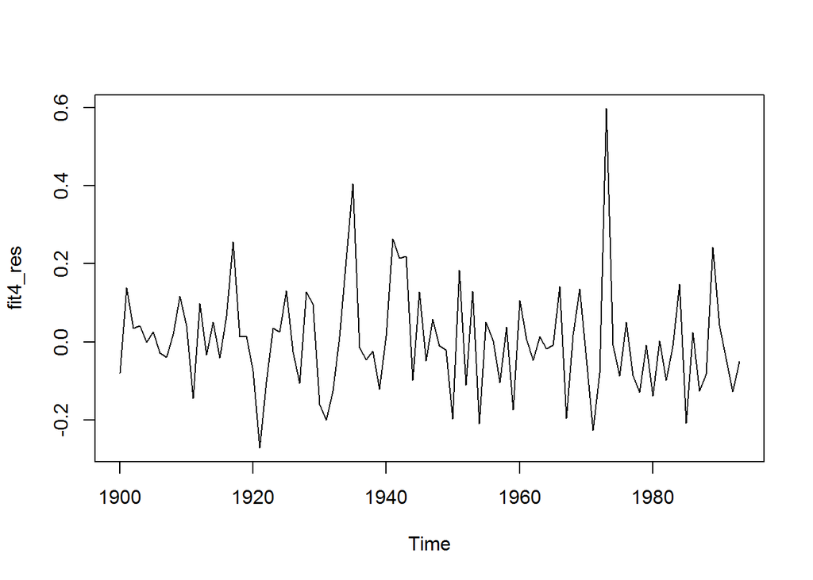

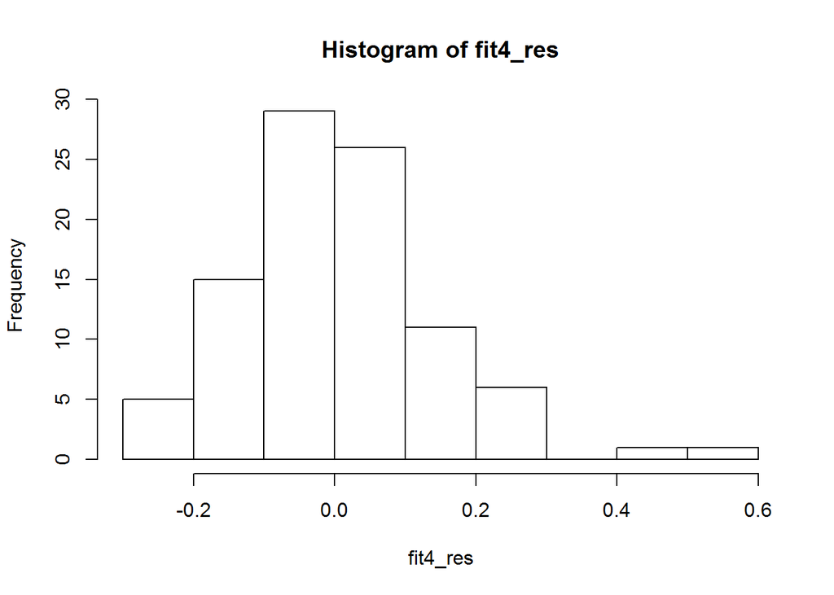

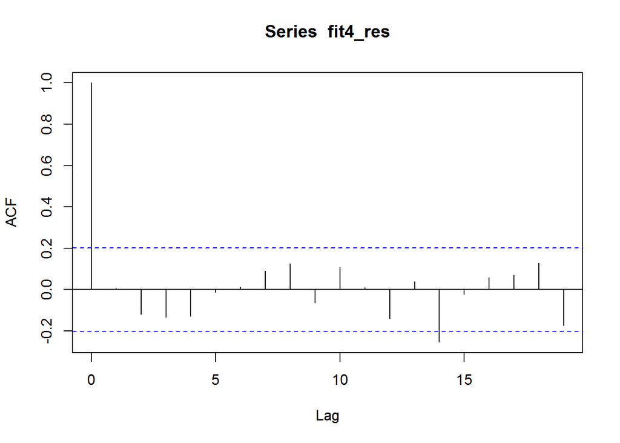

```r
mean(fit4_res)
```

```
## [1] 0.003847893
```

Residuals do look like white noise, because according to ACF graph, they are not autocorrelated. Furthermore, their mean is close to zero and according to histogram, they seem to be normally distributed.